# analysis

Varoon Bashyakarla

2025-01-14

## 1 Background

See the [README](https://github.com/vbashyakarla/tornado-mag/tree/main?tab=readme-ov-file#tornado-severity) file in this repository for background information. Below, a few models are constructed to predict tornado severity, and their performance is evaluated.

## 2 Setup

```r
knitr::opts_chunk$set(echo = TRUE, fig.path = "docs/images/", cache = TRUE)

library(embed)
library(finetune)
library(ggrepel)
library(kableExtra)
library(knitr)
library(poissonreg)
library(pscl)
library(RColorBrewer)
library(rmarkdown)
library(tidymodels)
library(tidyverse)
library(vip)
library(xgboost)

theme_set(theme_linedraw())
```

## 3 Import Data

```r
tornado_df <- read_csv("data/tornado.csv")
```

Preview of tornado_df

| om | yr | mo | dy | date | time | tz | datetime_utc | st | stf | mag | inj | fat | loss | slat | slon | elat | elon | len | wid | ns | sn | f1 | f2 | f3 | f4 | fc |
| --- | --- | --- | --- | --- | --- | --- | --- | --- | --- | --- | --- | --- | --- | --- | --- | --- | --- | --- | --- | --- | --- | --- | --- | --- | --- | --- |
| 192 | 1950 | 10 | 1 | 1950-10-01 | 21:00:00 | America/Chicago | 1950-10-02 03:00:00 | OK | 40 | 1 | 0 | 0 | 5e+04 | 36.73 | -102.52 | 36.88 | -102.30 | 15.8 | 10 | 1 | 1 | 25 | 0 | 0 | 0 | FALSE |
| 193 | 1950 | 10 | 9 | 1950-10-09 | 02:15:00 | America/Chicago | 1950-10-09 08:15:00 | NC | 37 | 3 | 3 | 0 | 5e+05 | 34.17 | -78.60 | 0.00 | 0.00 | 2.0 | 880 | 1 | 1 | 47 | 0 | 0 | 0 | FALSE |
| 195 | 1950 | 11 | 20 | 1950-11-20 | 02:20:00 | America/Chicago | 1950-11-20 08:20:00 | KY | 21 | 2 | 0 | 0 | 5e+05 | 37.37 | -87.20 | 0.00 | 0.00 | 0.1 | 10 | 1 | 1 | 177 | 0 | 0 | 0 | FALSE |
| 196 | 1950 | 11 | 20 | 1950-11-20 | 04:00:00 | America/Chicago | 1950-11-20 10:00:00 | KY | 21 | 1 | 0 | 0 | 5e+05 | 38.20 | -84.50 | 0.00 | 0.00 | 0.1 | 10 | 1 | 1 | 209 | 0 | 0 | 0 | FALSE |
| 197 | 1950 | 11 | 20 | 1950-11-20 | 07:30:00 | America/Chicago | 1950-11-20 13:30:00 | MS | 28 | 1 | 3 | 0 | 5e+04 | 32.42 | -89.13 | 0.00 | 0.00 | 2.0 | 37 | 1 | 1 | 101 | 0 | 0 | 0 | FALSE |
| 194 | 1950 | 11 | 4 | 1950-11-04 | 17:00:00 | America/Chicago | 1950-11-04 23:00:00 | PA | 42 | 3 | 1 | 0 | 5e+05 | 40.20 | -76.12 | 40.40 | -75.93 | 15.9 | 100 | 1 | 1 | 71 | 11 | 0 | 0 | FALSE |

Some of the column names are not self-explanatory. They are clarified below:

- `om` - Tornado ID (within the year)
- `stf` - State ID (specifically its Federal Information Processing Standards)
- `mag` - Tornado magnitude
- `inj` - Number of injuries
- `fat` - Number of fatalities
- `loss` - Estimated property damage (measured in ranges pre-1996, and the data show the maximum of the range)
- `slat`, `elat` - Starting / ending latitude (likewise for longitude)
- `ns` - Number of states impacted by tornado
- `sn` through `f4` - Various IDs (disregarded here)
- `fc` - Whether or not the magnitude of the tornado had been estimated

## 4 Exploratory Data Analysis

The outcome of interest is the tornado’s severity (i.e., its magnitude).

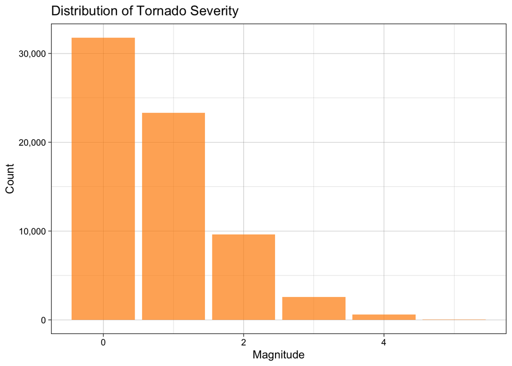

```r
tornado_df |>
  ggplot(aes(x = mag)) +
  geom_bar(fill = "darkorange", alpha = 0.7) +
  xlab("Magnitude") +
  ylab("Count") +
  ggtitle("Distribution of Tornado Severity") +
  scale_y_continuous(labels = scales::comma_format())
```

Most tornadoes are mild, but some are devastating and occur rarely. Additionally, as shown below, none of the magnitude 5 tornadoes had been predicted as such.

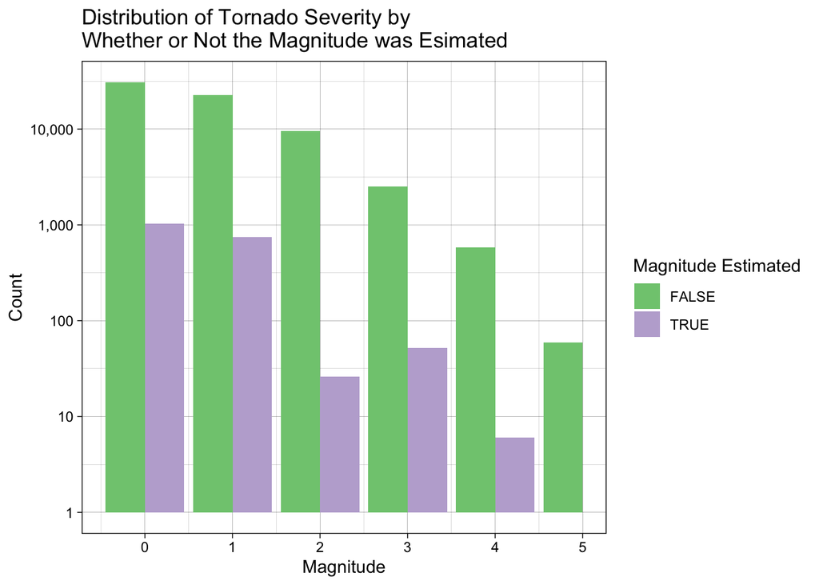

```r
tornado_df |>
  ggplot(aes(x = mag, fill = fc)) +
  geom_bar(position = position_dodge(preserve = "single")) +
  xlab("Magnitude") +
  ylab("Count") +
  ggtitle("Distribution of Tornado Severity by \nWhether or Not the Magnitude was Esimated") +
  scale_y_log10(labels = scales::comma_format()) +
  labs(fill = "Magnitude Estimated") +
  scale_fill_brewer(palette = "Accent")
```

The magnitude is a numeric value but not continuous.

- To predict it, we could treat this exercise as a classification problem, but doing so would lose information regarding the ordinality of the magnitude.
- An ordered logistic / probit regression is an option (using `MASS::polr()`).
- Treating the data-generating process as one that produces counts would lend itself to Poisson regression (using `poissonreg::poissonreg()`). However, both approaches risk failing to capture non-linearity in the data.
- XGBoost seems like a suitable option, but doing so requires us to treat the magnitude (the outcome of interest) as a continuous outcome. This is the model I have chosen to use.

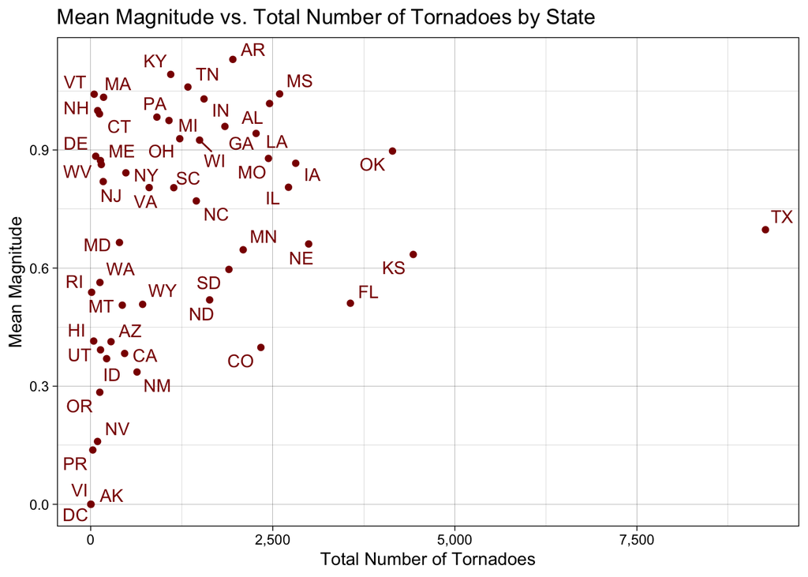

```r
tornado_df |>
  group_by(st) |>
  summarise(mean_mag = mean(mag, na.rm = TRUE),
            n = n()) |>
  ggplot(aes(x = n, y = mean_mag, label = st)) +
  geom_point(color = "darkred") +
  geom_text_repel(color = "darkred") +
  xlab("Total Number of Tornadoes") +
  ylab("Mean Magnitude") +
  ggtitle("Mean Magnitude vs. Total Number of Tornadoes by State") +
  scale_x_continuous(labels = scales::comma_format())
```

This graph is clearly non-random. State information is associated with magnitude. As we know, some states have more frequent occurrences of tornadoes, and the magnitude is not evenly distributed across states.

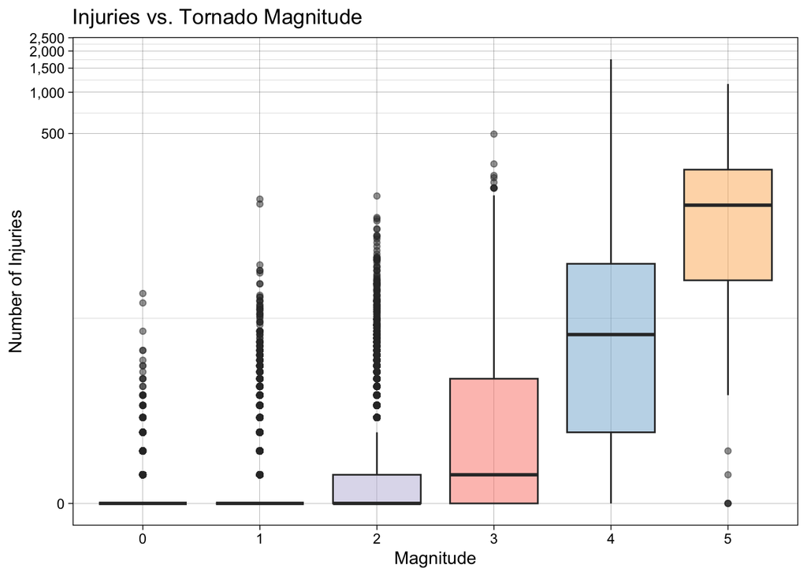

```r
tornado_df |>
  filter(!is.na(mag)) |>
  mutate(mag = factor(mag)) |>
  ggplot(aes(x = mag, y = inj, fill = mag)) +
  geom_boxplot(alpha = 0.5, show.legend = FALSE) +
  scale_y_log10(trans = scales::pseudo_log_trans(base = 10),
                # helpful when visualizing log data when many observations are 0
                labels = scales::comma_format()) +
  scale_fill_brewer(palette = "Set3") +
  xlab("Magnitude") +
  ylab("Number of Injuries") +
  ggtitle("Injuries vs. Tornado Magnitude")
```

As expected, higher magnitude tornadoes are associated with more injuries, though plenty of outliers exist. We see similar trends for fatalities, as shown below, but the effect is dampened.

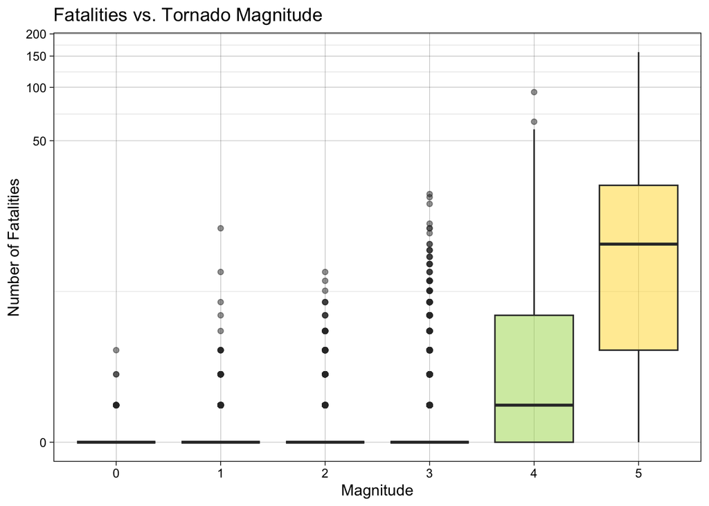

```r
tornado_df |>
  filter(!is.na(mag)) |>
  mutate(mag = factor(mag)) |>
  ggplot(aes(x = mag, y = fat, fill = mag)) +
  geom_boxplot(alpha = 0.5, show.legend = FALSE) +
  scale_y_log10(trans = scales::pseudo_log_trans(base = 10),
                labels = scales::comma_format()) +
  scale_fill_brewer(palette = "Set2") +
  xlab("Magnitude") +
  ylab("Number of Fatalities") +
  ggtitle("Fatalities vs. Tornado Magnitude")
```

## 5 Set Up Framework

Because the outcome of interest is so unevenly distributed, training and test sets are built using stratified sampling.

```r
# Defining Training (Analysis and Assessment) Datasets and Test Sets
set.seed(1234)

tornado_split_df <-
  tornado_df |>
  filter(!is.na(mag),
         !is.na(loss)) |>
  initial_split(strata = mag) # default 75% train, 25% test

tornado_train <- training(tornado_split_df)
tornado_test <- testing(tornado_split_df)

# xval resamples
set.seed(123)
tornado_folds <- vfold_cv(tornado_train, strata = mag)
tornado_folds # 10 folds by default
```

```
## #  10-fold cross-validation using stratification
## # A tibble: 10 × 2
##    splits               id
##    <list>               <chr>
##  1 <split [28021/3115]> Fold01
##  2 <split [28021/3115]> Fold02
##  3 <split [28021/3115]> Fold03
##  4 <split [28022/3114]> Fold04
##  5 <split [28023/3113]> Fold05
##  6 <split [28023/3113]> Fold06
##  7 <split [28023/3113]> Fold07
##  8 <split [28023/3113]> Fold08
##  9 <split [28023/3113]> Fold09
## 10 <split [28024/3112]> Fold10
```

## 6 Pre-Processing and Feature Engineering

In order to capture state-specific effects without increasing the number of inputs by ~50 via one-hot encoding, we can use effect encodings. The code below uses linear embeddings for state-level variables via a generalized linear model. It also extracts month and year information from dates and one-hot encodes month inputs.

```r
tornado_recipe <-
  recipe(mag ~ date + st + inj + fat + len + wid + ns,
         data = tornado_train) |>
  # maps states to effect on the outcome
  step_lencode_glm(st, outcome = vars(mag)) |>
  step_date(date, features = c("month", "year"), keep_original_cols = FALSE) |>
  # change existing nominal variables to dummy / indicators
  step_dummy(all_nominal_predictors())

# tornado_recipe
```

Here, we are modeling the tornado’s magnitude as a function of:

- `date` - When the tornado occurred
- `st` - The state in which the tornado started
- `inj` - The number of injuries caused by the tornado
- `fat` - The number of fatalities
- `len` - The length of the tornado (measured in miles)
- `wid` - The width of the tornado (measured in yards)
- `ns` - The number of states affected by the tornado

```r
# For debugging
prep(tornado_recipe) |> bake(new_data = NULL) |> glimpse()
```

```
## Rows: 31,136
## Columns: 19
## $ st             <dbl> 1.2663014, 1.1072304, 1.0354342, 1.0354342, 1.0864012, …
## $ inj            <dbl> 0, 3, 0, 32, 2, 0, 2, 0, 0, 0, 0, 0, 0, 0, 0, 1, 0, 0, …
## $ fat            <dbl> 0, 0, 0, 0, 0, 0, 0, 0, 0, 0, 0, 0, 0, 0, 0, 0, 0, 0, 0…
## $ len            <dbl> 15.8, 2.0, 2.3, 7.7, 2.0, 0.5, 0.1, 0.2, 2.0, 19.8, 0.5…
## $ wid            <dbl> 10, 37, 233, 100, 33, 27, 10, 10, 100, 10, 77, 10, 27, …
## $ ns             <dbl> 1, 1, 1, 1, 1, 1, 1, 1, 1, 1, 1, 1, 1, 1, 1, 1, 1, 1, 1…
## $ mag            <dbl> 1, 1, 1, 1, 1, 1, 1, 1, 1, 1, 1, 1, 1, 1, 1, 1, 1, 0, 0…
## $ date_year      <int> 1950, 1950, 1950, 1950, 1950, 1950, 1950, 1950, 1950, 1…
## $ date_month_Feb <dbl> 0, 0, 1, 1, 0, 0, 0, 0, 0, 0, 0, 0, 0, 0, 0, 0, 0, 0, 0…
## $ date_month_Mar <dbl> 0, 0, 0, 0, 1, 1, 1, 1, 0, 0, 0, 0, 0, 0, 0, 0, 0, 0, 0…
## $ date_month_Apr <dbl> 0, 0, 0, 0, 0, 0, 0, 0, 1, 1, 0, 0, 0, 0, 0, 0, 0, 0, 0…
## $ date_month_May <dbl> 0, 0, 0, 0, 0, 0, 0, 0, 0, 0, 1, 1, 1, 1, 1, 1, 1, 1, 1…
## $ date_month_Jun <dbl> 0, 0, 0, 0, 0, 0, 0, 0, 0, 0, 0, 0, 0, 0, 0, 0, 0, 0, 0…
## $ date_month_Jul <dbl> 0, 0, 0, 0, 0, 0, 0, 0, 0, 0, 0, 0, 0, 0, 0, 0, 0, 0, 0…
## $ date_month_Aug <dbl> 0, 0, 0, 0, 0, 0, 0, 0, 0, 0, 0, 0, 0, 0, 0, 0, 0, 0, 0…
## $ date_month_Sep <dbl> 0, 0, 0, 0, 0, 0, 0, 0, 0, 0, 0, 0, 0, 0, 0, 0, 0, 0, 0…
## $ date_month_Oct <dbl> 1, 0, 0, 0, 0, 0, 0, 0, 0, 0, 0, 0, 0, 0, 0, 0, 0, 0, 0…
## $ date_month_Nov <dbl> 0, 1, 0, 0, 0, 0, 0, 0, 0, 0, 0, 0, 0, 0, 0, 0, 0, 0, 0…
## $ date_month_Dec <dbl> 0, 0, 0, 0, 0, 0, 0, 0, 0, 0, 0, 0, 0, 0, 0, 0, 0, 0, 0…
```

As the output above shows, the state-level information is not one-hot encoded (which would have increased the number of inputs dramatically) but remains a single column in which each value represents a state-specific deviation from the data when considering all states together.

## 7 XGBoost

### 7.1 Model Specification and Hyperparameter Tuning via Racing

```r
xgb_details <-
  boost_tree(
    trees = tune(),
    min_n = tune(),
    mtry = tune(),
    learn_rate = 0.005, # shrinkage
    engine = "xgboost"
  ) |>
  set_mode("regression")

xgb_workflow <- workflow(preprocessor = tornado_recipe, spec = xgb_details)
xgb_workflow
```

```
## ══ Workflow ════════════════════════════════════════════════════════════════════
## Preprocessor: Recipe
## Model: boost_tree()
##
## ── Preprocessor ────────────────────────────────────────────────────────────────
## 3 Recipe Steps
##
## • step_lencode_glm()
## • step_date()
## • step_dummy()
##
## ── Model ───────────────────────────────────────────────────────────────────────
## Boosted Tree Model Specification (regression)
##
## Main Arguments:
##   mtry = tune()
##   trees = tune()
##   min_n = tune()
##   learn_rate = 0.005
##
## Computational engine: xgboost
```

- The hyperparameters being tuned via grid search are:
- `trees` - The number of trees used in the ensemble.
- `min_n` - The minimum number of observations required at a node before the node is split further.
- `mtry` - The number of predictors randomly sampled at each split during tree model creation.

The `learn_rate` was set to `0.005` to keep local computations tractable.

The hyperparameters are selected and tuned via racing in which unpromising parameters are eliminated (based on the outcomes of ANOVA) to save processing time.

The model runs one set of hyperparameters on each of the 10 cross-validation folds through racing. Poor-performing hyperparameters (based on the outcomes of ANOVA) are eliminated to save processing time. The process continues until the best hyperparameters have been identified.

```r
set.seed(456)

xgb_tuning_rs <- tune_race_anova(
  xgb_workflow,
  resamples = tornado_folds, # used for tuning
  grid = 20,
  # metrics = "rmse",
  control = control_race(verbose_elim = TRUE)
)
```

```
## ℹ Evaluating against the initial 3 burn-in resamples.
## ℹ Racing will minimize the rmse metric.
## ℹ Resamples are analyzed in a random order.
## ℹ Fold07: 13 eliminated; 7 candidates remain.
##
## ℹ Fold09: 5 eliminated; 2 candidates remain.
##
## ℹ Fold08: 0 eliminated; 2 candidates remain.
##
## ℹ Fold06: 0 eliminated; 2 candidates remain.
##
## ℹ Fold10: 0 eliminated; 2 candidates remain.
##
## ℹ Fold03: 0 eliminated; 2 candidates remain.
##
## ℹ Fold05: 0 eliminated; 2 candidates remain.
```

### 7.2 Race Results, Hyperparameter Configuration, and Model Finalization

XGBoost hyperparameter tuning results

| mtry | trees | min_n | .metric | .estimator | mean | n | std_err | .config |
| --- | --- | --- | --- | --- | --- | --- | --- | --- |
| 10 | 1769 | 18 | rmse | standard | 0.6294387 | 10 | 0.0034096 | Preprocessor1_Model12 |
| 10 | 1769 | 18 | rsq | standard | 0.5280181 | 10 | 0.0056591 | Preprocessor1_Model12 |
| 12 | 1912 | 31 | rmse | standard | 0.6291582 | 10 | 0.0033479 | Preprocessor1_Model13 |
| 12 | 1912 | 31 | rsq | standard | 0.5284401 | 10 | 0.0055258 | Preprocessor1_Model13 |

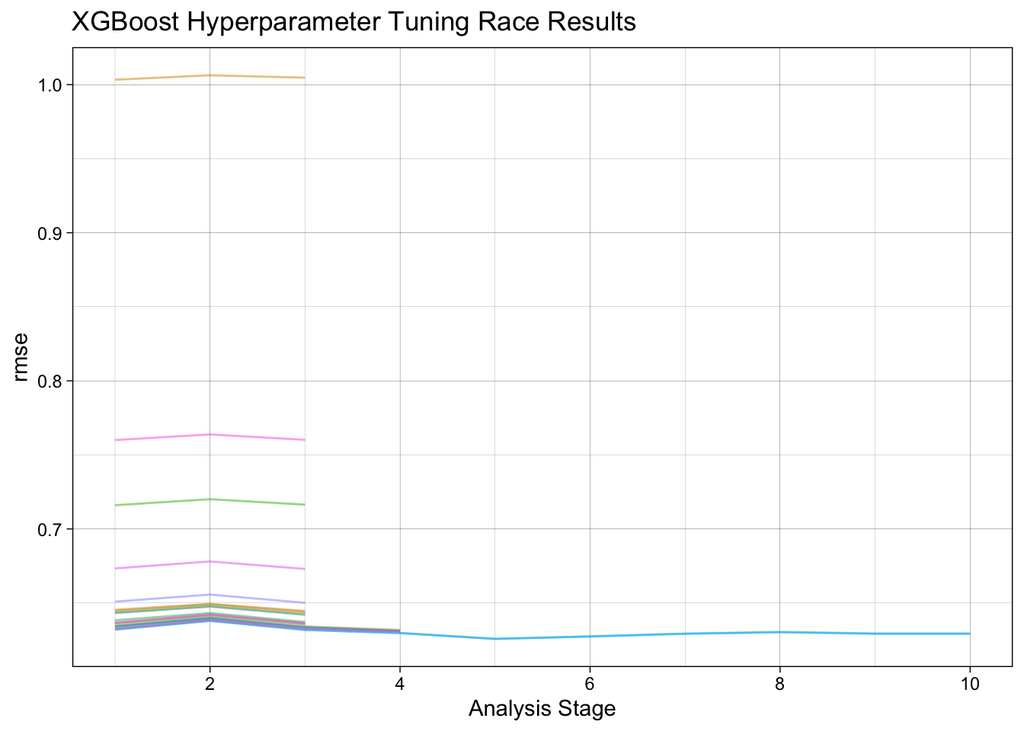

```r
select_best(xgb_tuning_rs, metric = "rmse")
```

Best-performing XGBoost hyperparameters

| mtry | trees | min_n | .config |
| --- | --- | --- | --- |
| 12 | 1912 | 31 | Preprocessor1_Model13 |

Using rmse as our evaluation metric, the hyperparameters for the best model were found as shown above.

### 7.3 XGBoost Model Fit and Performance

With the hyperparameters tuned, we can now fit the model once on the full set of training data and evaluate its performance on the test data.

```r
tornado_fit <-
  xgb_workflow |>
  finalize_workflow(select_best(xgb_tuning_rs, metric = "rmse")) |>
  last_fit(tornado_split_df)
```

XGBoost evaluation metrics on testing data

| .metric | .estimator | .estimate | .config |
| --- | --- | --- | --- |
| rmse | standard | 0.6268218 | Preprocessor1_Model1 |
| rsq | standard | 0.5325212 | Preprocessor1_Model1 |

Given the hyperparameter tuning results, the outcome metrics here do not suggest that we have overfit the model in training. The model explains about 53% of the variance in observed magnitudes. (For more on the risks of referencing r-squared metrics in the presence of non-linearity, see the “Model Comparison” section below.)

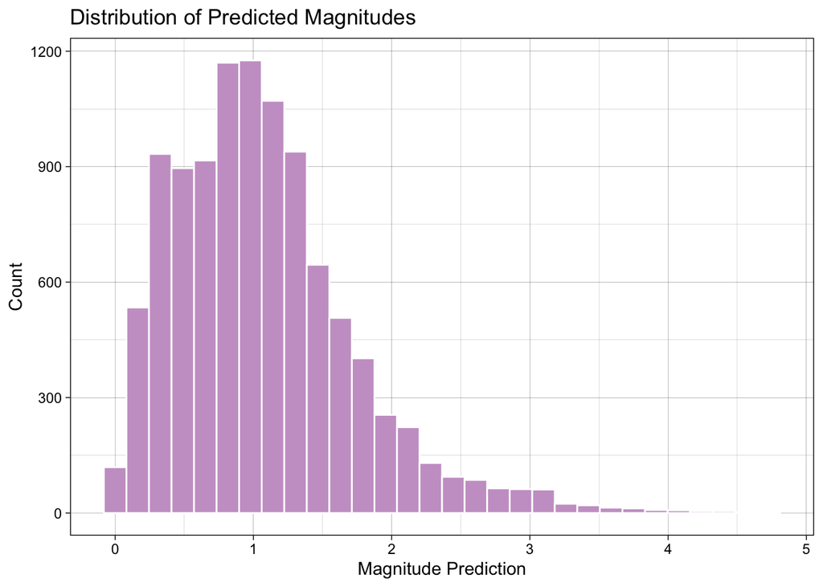

```r
collect_predictions(tornado_fit) |>
  ggplot(aes(x = .pred)) +
  geom_histogram(bins = 30, fill = "#CAA1CC", col = "white") +
  xlab("Magnitude Prediction") +
  ylab("Count") +
  ggtitle("Distribution of Predicted Magnitudes")
```

Though we treated the magnitude as a continuous variable, we have not predicted many magnitudes less than 0. Relative to the true distribution of magnitudes, this model outputs predictions that are biased in favor of mid-range values. In other words, we are predicting low-magnitude tornadoes to be higher in magnitude and higher-magnitude tornadoes as lower in magnitude. The plot below demonstrates this aspect of the model’s performance more clearly.

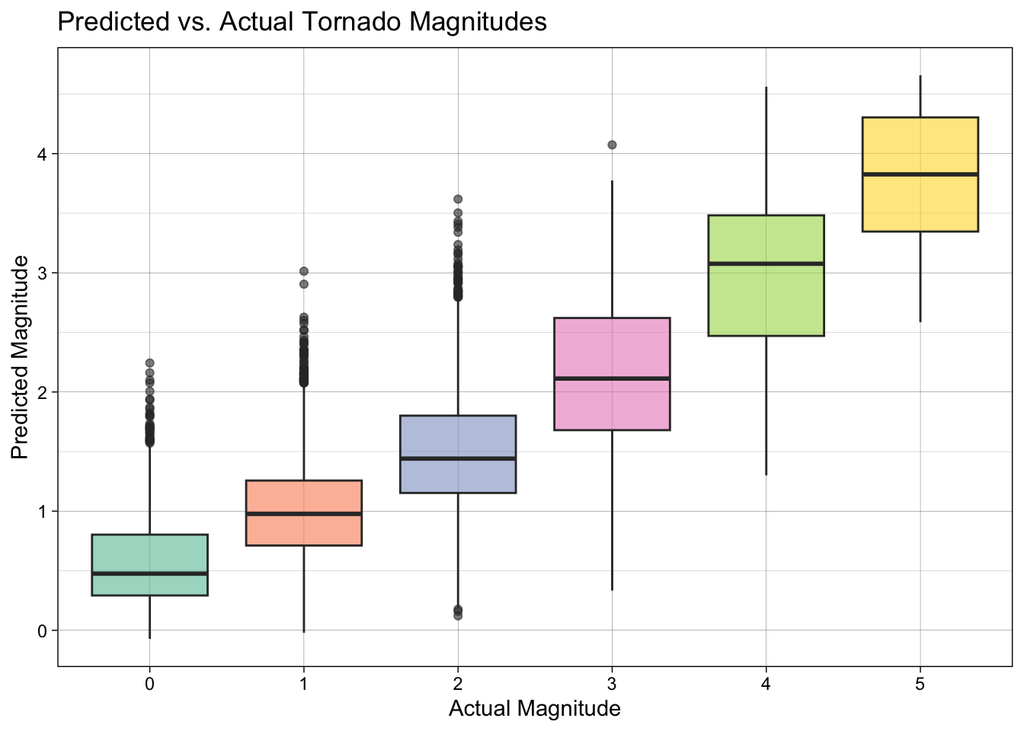

```r
collect_predictions(tornado_fit) |>
  mutate(mag = factor(mag)) |>
  ggplot(aes(x = mag, y = .pred, fill = mag)) +
  geom_boxplot(alpha = 0.6, show.legend = FALSE) +
  scale_fill_brewer(palette = "Set2") +
  xlab("Actual Magnitude") +
  ylab("Predicted Magnitude") +
  ggtitle("Predicted vs. Actual Tornado Magnitudes")
```

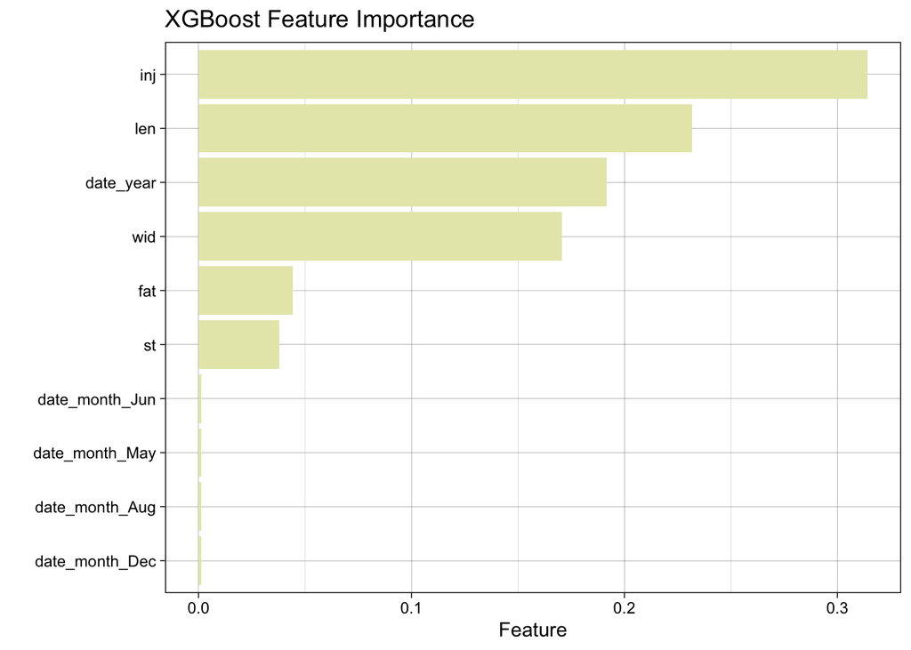

```r
extract_workflow(tornado_fit) |>
  extract_fit_parsnip() |>
  vip(num_features = 10) +
  geom_bar(stat = "identity", fill = "#E6E8B7") +
  ylab("Feature") +
  ggtitle("XGBoost Feature Importance")
```

The features deemed important by the model are the following:

- The number of injuries
- The length of the tornado
- The year in which the tornado occurred
- The width of the tornado
- The number of fatalities resulting from the tornado
- The state in which the tornado started
- Month-level data

The importance of the state variable suggests that the effect encoding was sensible.

Is it possible that some of the models considered above can outperform this model? Let’s give another model a try.

## 8 Poisson Regression

Can we consider the process that generates the resulting magnitude distribution as a count-generating one that follows a Poisson distribution? As stated above, modeling the magnitude outcomes is also possible using Poisson regression, but doing so fails to capture non-linearity in the model. The code below estimates tornado magnitude using Poisson regression.

### 8.1 Poisson Regression via Generalized Linear Modeling Estimation

```r
poisson_recipe <- tornado_recipe
pr_spec <- poisson_reg(engine = "glm")
pr_workflow <- workflow(preprocessor = poisson_recipe, spec = pr_spec)
pr_fit <- pr_workflow |> fit(tornado_train)
pr_preds <-  predict(pr_fit, tornado_test) |> bind_cols(tornado_test)
pr_rs <- rmse(pr_preds, truth = mag, estimate = .pred) |>
  rbind.data.frame(rsq(pr_preds, truth = mag, estimate = .pred))
```

Poisson regression evaluation metrics on out-of-sample data

| .metric | .estimator | .estimate |
| --- | --- | --- |
| rmse | standard | 0.8968473 |
| rsq | standard | 0.1687936 |

### 8.2 Zero-Inflated Poisson Regression

Nearly half of all the tornadoes in this data have magnitude 0. Because Poisson regression predicts counts, perhaps an improvement can be realized with zero-inflated poisson regression, which models zero and non-zero counts separately since separate processes could be generating these two count outcomes. The code below predicts tornado magnitudes using zero-inflated Poisson regression. Only the top three features from XGBoost (i.e., the number of injuries, tornado length, and year) are used to predict zero-count outcomes.

```r
# Zero-inflated Poisson
# one piece of the model predicts the 0s and the other predicts the counts

zip_spec <- poisson_reg() |> set_engine("zeroinfl")
zip_wf <- workflow(preprocessor = poisson_recipe) |>
  add_model(zip_spec, formula = mag ~ date_month_Feb + date_month_Mar + date_month_Apr + date_month_May + date_month_Jun + date_month_Jul + date_month_Aug + date_month_Sep + date_month_Oct + date_month_Nov + date_month_Dec + date_year + st + inj + fat + len + wid + ns | inj + len + date_year) # top 3 var imp
zip_fit <- zip_wf %>% fit(tornado_train)
```

```
## Warning: glm.fit: fitted probabilities numerically 0 or 1 occurred
```

```r
zip_preds <- predict(zip_fit, tornado_test) |>  bind_cols(tornado_test)
zip_rs <- rmse(zip_preds, truth = mag, estimate = .pred) |>
  rbind.data.frame(rsq(zip_preds, truth = mag, estimate = .pred))
```

Zero-inflated poissson regression evaluation metrics on testing data

| .metric | .estimator | .estimate |
| --- | --- | --- |
| rmse | standard | 0.8385205 |
| rsq | standard | 0.2230320 |

The zero-inflation improved performance metrics; the out-of-sample R-squared value increased while the RMSE decreased. It should be noted that warning output by the engine fitting the model may have resulted from the fact that some outcomes (e.g., magnitude = 5) are extremely rare, causing outcomes with probabilities of 0 to put generated. This could be addressed, or at least ameliorated, through the use of regularization and / or bootstrapping, as the coefficients resulting from the model may have high variance.

## 9 Model Comparison

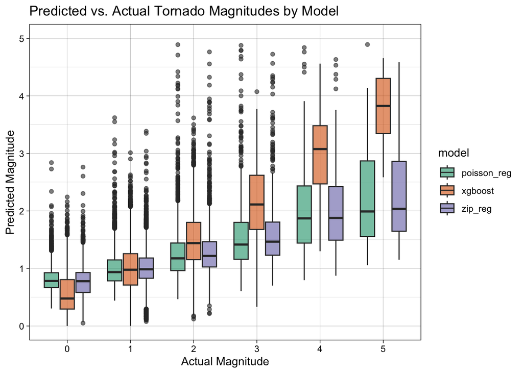

```r
collect_predictions(tornado_fit) |> mutate(model = "xgboost") |> select(mag, .pred, model) |>
  rbind.data.frame(pr_preds |> mutate(model = "poisson_reg") |> select(mag, .pred, model)) |>
  rbind.data.frame(zip_preds |> mutate(model = "zip_reg") |> select(mag, .pred, model)) |>
  mutate(mag = factor(mag)) |>
  ggplot(aes(x = mag, y = .pred, fill = model)) +
  geom_boxplot(alpha = 0.6, show.legend = TRUE) +
  scale_fill_brewer(palette = "Dark2") +
  xlab("Actual Magnitude") +
  ylab("Predicted Magnitude") +
  ggtitle("Predicted vs. Actual Tornado Magnitudes by Model") +
  ylim(0, 5)
```

Of the three models, XGBoost predictions appear the most adaptable and closest to the true magnitude observations. Based on this visualization alone, the performance of the two Poisson regression models are virtually indistinguishable. Even for magnitude 5 tornado, these Poisson regression models appear to be outputting predictions with a median magnitude of about 2 (vs. ~3.75 for XGBoost).

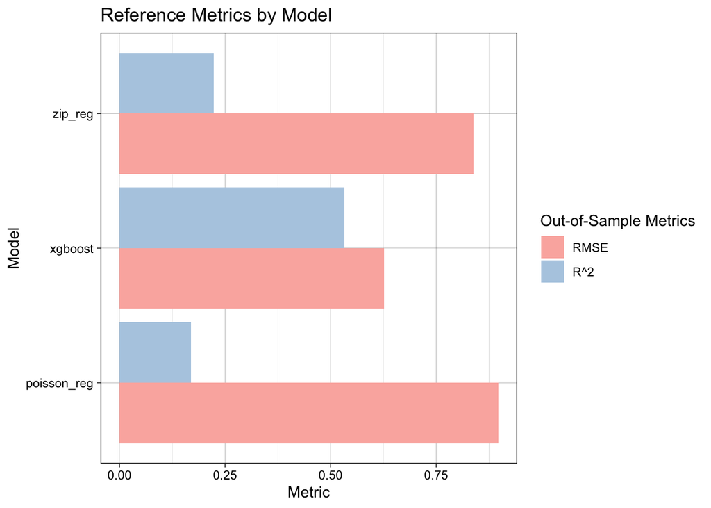

The primary evaluation criterion used here is the root mean squared error. Based on this metric alone, XGBoost appears to be the best-performing model. The results suggest that the underlying relationship between the magnitude of tornado and the features explored here are non-linear. Both poisson regression models fail to capture non-linear relationships, and their associated rmse metrics are considerably larger. The interpretation of r-squared as a goodness of fit metric in the presence of non-linearity must be used with caution. It is presented here as a reference. If the Poisson regression models had markedly improved predictive outcomes, then it would have beeen reasonable to assume that the underlying relationship is comprised of fewer non-linear effects.

While both Poisson regression models here were trained without any additional improvements (e.g., bootstrapping, cross-validation, etc.), it appears unlikely that these extensions would improve the models sufficiently to overcome their performance deficit relative to XGBoost. Still, enlisting these techniques may have generated more stable coefficients in the zero-inflated Poisson regression, as described above.